# PID Systems

Feedback control loops can be used to build systems controlling real apparatus, eg. a heater.

Aims:

- To build a working thermostat system with a resistance heater (heat in) and natural cooling (heat out)
- To program a PID control loop to adjust the heater temperature

Context:

- Plant (heater) - device being controlled. Operates with respect to a setpoint of our choosing.
- Sensor (thermocouple) - registers the plant operation, i.e. by taking a measurement.
- Error - the difference between setpoint and sensor output.
- Controller - contains remaining filters and amplifiers

Considerations:

- Heat flowing in from the resistance heater (heating, see heat distribution, heat equation)
- Heat lost to environment (cooling, see heat distribution, heat equation)
- Upper limit of heater (25W)
- Lower limit of liquid nitrogen temperature ($H = Ae\sigma T^4$)

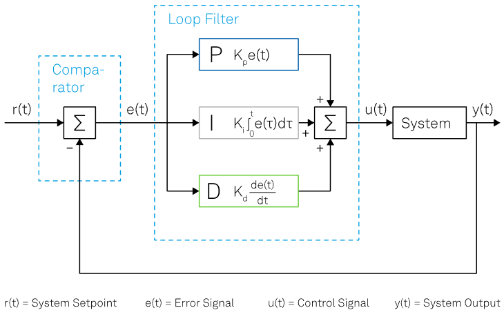

The main feature of the system is that it is self-correctional, meaning that when the thermocouple detects a new temperature, the error signal $ \neq 0 $ and the system responds by turning the heater on or off. The signal is modified by a PID Loop filter, which is a standard feedback control loop consisting of three different processes acronymised as PID - Proportional, Integral and Derivative Control. This is a correctional filter which decides the extent to which the system responds - how much heating or cooling there is.

```python
import numpy as np
import matplotlib.pyplot as plt
import scipy.optimize as optimize
from PIL import Image
import time
```

```python
#timer

#timestep = 0.5*10**(-3)
#mintime = 1*10**(-3)

#if timestep > mintime:
#    start_time = time.perf_counter()     #start time, starts when error signal =/= 0
#    time.sleep(timestep)                 #timestep- time over which the temperature is measured
#    end_time = time.perf_counter()       #end time, stops when error signal = 0
#    time_elapsed = end_time - start_time #how long the timer ran for
#else:
#    timestep = mintime
```

```python
#comparitor
#finds the difference between the current state and desired state
#this creates an error signal which is fed back through to the comparator such that
#the error signal is iteratively updated wrt. time as PV(t) changes relative to the setpoint

#effective to use class objects to call our PID functions-
#makes the code easier to call in later parts, and easier to change

class PID:
    def __init__(self, Kp, Ki, Kd, setpoint):
        self.Kp = Kp
        self.Ki = Ki
        self.Kd = Kd
        self.setpoint = setpoint
        self.integral = 0
        self.previous_error = 0

    def loop(self, temp, dt):
            error = self.setpoint - temp
            P = self.Kp * error

            self.integral += error * dt
            I = self.Ki * self.integral

            derivative = (error - self.previous_error) *1/(dt)
            D = self.Kd * error *1/(dt)

            sumPID = P + I + D
            self.previous_error = error

            return sumPID
```

```python
#proportionality constants - see Ziegler Nichols Method
Kp = 1
Ki = 0
Kd = 0.3

#experiment parameters
a = 1.15e-4

temp = []
setpoint = 120
current_temp = 300

#time
t0 = 0
t1 = 10
step = 100

time = np.linspace(t0, t1, step)
dt = time[1] - time[0]

#Simulation
pid = PID(Kp, Ki, Kd, setpoint)

for t in time:
    output = pid.loop(current_temp, dt)

    # Simulate process dynamics (heating rate proportional to control output)
    current_temp += output*dt - a*(current_temp)*dt  # Heat loss
    temp.append(current_temp)
```

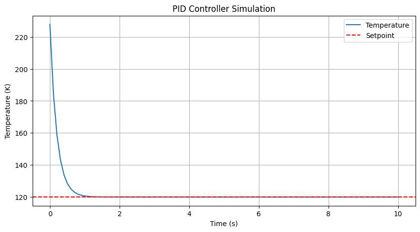

```python
#Plot
plt.figure(figsize=(10, 5))
plt.plot(time, temp, label='Temperature')
plt.axhline(y=setpoint, color='red', linestyle='--', label='Setpoint')
plt.xlabel('Time (s)')
plt.ylabel('Temperature (K)')
plt.title('PID Controller Simulation')
plt.legend()
plt.grid()
plt.show()
```